# 1 Part I: The Cake Eating Problem

In this note, I hope to be more familiar with creating a Python class to represent an economics model, and to be more familiar with NumPy type hinting to track the calculation process, and to perform unit tests when developing codes.

## 1.1 Problem Setup

Suppose that we are presented with a cake of size $W_0$ at time $0$. At each period of time $t = 0, 1, \ldots$, you can eat some of the cake but must save the rest. Let $c_t$ be your consumption in period $t$, and let $u(c_t)$ represent the flow of utility from this consumption. Here, we use $u(c) = \log(c)$, which is real valued, differentiable, strictly increasing, and strictly concave, and $\lim_{c \rightarrow 0^+} u^\prime(c) = +\infty$. Therefore, the problem is

$$\begin{aligned}
\max_{\{c_t\}_{t=0}^{\infty}} & \sum_{t=0}^{\infty} \beta^t u(c_t) \\
\text{s.t. } & W_{t+1} = W_t - c_t, \\
& c_{t}\geq 0,\; W_{t+1} \geq 0, \; t = 0, 1, \ldots; \\
\text{given } & W_0 > 0.
\end{aligned}$$

The Bellman equation associated with this problem is

$$V(W_t) = \max_{0 \leq c_t \leq W_t} \left\{u(c_t) + \beta V(\underbrace{W_{t+1}}_{=W_t - c_t} )\right\}$$

### 1.1.1 Analytical Solution

We start with a guess that

$$V(W) = A + B \log(W),$$

where $A$ and $B$ are coefficients to be determined. Given this conjecture, we can write the Bellman equation as

$$A+B \log (W)=\max _c\left\{\log c+\beta \left(A+B \log (W-c) \right)\right\}.$$

The FOC is

$$\frac{1}{c}-\frac{\beta B}{W-c}=0 \quad \Rightarrow \quad c=\frac{W}{1+\beta B},\; W-c=\frac{\beta B W}{1+\beta B}.$$

Then we have
$$\begin{aligned}
A+B \log (W)= & \log (W)+\log \frac{1}{1+\beta B}+\beta A+\beta B \log (W)+\beta B \log \frac{\beta B}{1+\beta B} \\
\Rightarrow & \left\{\
\begin{array}{ll}
& A=\beta A+\log \frac{1}{1+\beta B}+\beta B \log \frac{\beta B}{1+\beta B} \\
& B=1+\beta B
\end{array}\right.
\end{aligned}$$

After some algebraic calculation, we can obtain the analytic solution to this simple cake-eating problem:

$$\begin{aligned}
& c^{\star}(W)=(1-\beta) W \\
& V(W)=\frac{\log (W)}{1-\beta}+\frac{\log (1-\beta)}{1-\beta}+\frac{\beta \log (\beta)}{(1-\beta)^2}
\end{aligned}$$

### 1.1.2 A Python Class to Represent the Problem

First, there are two model parameters, $\beta$ and $W_0$. However, these two economics parameters are not enough to represent this problem in a computer, we need other numerical parameters to solve the problem, which are all set to be optional arguments when initializing an instance.

```python
import numpy as np
import matplotlib.pyplot as plt
from scipy import interpolate
from cycler import cycler

# && type hinting relevant variables
from typing import Annotated, Literal, TypeVar, Union
import numpy.typing as npt

DType = TypeVar("DType", bound=np.generic)
ArrayNxN = Annotated[npt.NDArray[DType], Literal["ngridw", "ngridw"]]
ArrayNxNc = Annotated[npt.NDArray[DType], Literal["ngridw", "ngridc"]]
ArrayN = Annotated[npt.NDArray[DType], Literal["ngridw"]]
Collection_float = Union[ArrayN[np.float64], ArrayNxN[np.float64], np.float64]
Numerical_pars = Union[dict[str, float], dict[str, int]]


class CakeEating:
    """
    This class solves the cake-eating problems using different numerical
    methods.

    Through this script, I hope to be more familiar with creating a
    Python class to represent an economics model, and to be more
    familiar with NumPy type hinting to track the calculation process,
    and to perform unit tests when developing codes.
    """

    def __init__(
        self,
        beta: float = 0.9,
        w0: float = 10,
        **kwargs: Numerical_pars,
    ) -> None:
        """
        Initialize an object instance with model parameters, and
        possibly numerical parameters.
        """

        # -? model parameters
        self.beta = beta
        self.w0 = w0

        # -? numerical parameters
        self.kwargs = kwargs
        if "ngridw" in kwargs:
            assert isinstance(
                kwargs["ngridw"], int
            ), "ngridw should be an integer!"
            self.ngridw = kwargs["ngridw"]
        else:
            self.ngridw = 100

        if "ngridc" in kwargs:
            assert isinstance(
                kwargs["ngridc"], int
            ), "ngridc should be an integer!"
            self.ngridc = kwargs["ngridc"]
        else:
            self.ngridc = 200

        if "adapted_grid_c" in kwargs:
            assert isinstance(
                kwargs["adapted_grid_c"], bool
            ), "adapted_grid_c should be a boolen"
            self.adapted_grid_c = kwargs["adapted_grid_c"]
        else:
            self.adapted_grid_c = True

        if "max_iter" in kwargs:
            assert isinstance(
                kwargs["max_iter"], int
            ), "max_iter should be an integer!"
            self.max_iter = kwargs["max_iter"]
        else:
            self.max_iter = 1000

        if "relative_error" in kwargs:
            assert isinstance(
                kwargs["relative_error"], bool
            ), "relative_error should be a boolen"
            self.relative_error = kwargs["relative_error"]
        else:
            self.relative_error = False

        if "c_min" in kwargs:
            assert isinstance(kwargs["c_min"], float)
            self.c_min = kwargs["c_min"]
        else:
            self.c_min = 1e-10

        if "tol" in kwargs:
            assert isinstance(kwargs["tol"], float)
            self.tol = kwargs["tol"]
        else:
            self.tol = 1e-4

    def __repr__(self) -> str:
        numerical_parameters = [str((par, self.kwargs[par])) for par in self.kwargs]
        return (
            f"A simple cake-eating problem with beta = {self.beta:.2f}, "
            f"and initial wealth W_0 = {self.w0:.3f}.\n"
            f"Other non-default numerical parameters are set to "
            f"{', ' .join(numerical_parameters)}."
        )
```

**1**

I use type hinting for the model parameters, as they are often soft requirements, and we are very unlikely to pass wrong types to these arguments.

**2**

I collect the numerical parameters as optional arguments, as these parameters depend on which numerical methods we are using, so they can vary case by case. Essentially, an economics model is only represented by the model parameters.

**3**

For the numerical parameters, I use strong `assert` statements to check the passing numerical parameters, since this is more likely to be sources of mistakes.

### 1.1.3 Unit Tests

How can we make sure that our class works just as our expectation, even though only the constructor has been coded up? One important approach is to perform unit tests, which specifically test this unit of codes.

In principle, we can manually check if our constructor gets the same results as our expectations. For example,

```python
model1 = CakeEating()
print(model1)
model1.beta
model1.w0
model1.ngridw
model1.c_min
model1.tol

model4 = CakeEating(beta = 0.66, ngridw=1000, c_min=1e-5)
model4.beta
model4.w0
model4.ngridw
model4.c_min
model4.tol

# model_wrongNtype = CakeEating(ngridw=10.0)
#     AssertionError: ngridw should be an integer!
```

Executing the final line will throw out an error message, which is exactly what we want – a strict type checking for numerical parameters. However, a better way to perform these tests is using certain testing framework, which can greatly reduce our burden.

```
test_CakeEating.py
```

```python
# | eval: false

import CakeEating as CE

import pytest

def test_init_model_pars():
    model1 = CE.CakeEating()
    assert model1.beta == 0.90
    assert model1.w0 == pytest.approx(100.0)

    model2 = CE.CakeEating(beta=0.66)
    assert model2.beta == pytest.approx(0.66)


def test_init_numerical_types():
    model3 = CE.CakeEating(ngridw=99.0)
    assert model3.ngridw == 99

# def test_init_numerical_types_elegant():
#     with pytest.raises(AssertionError):
#         model3 = CE.CakeEating(ngridw=99.0)
#         assert model3.ngridw == 99

def test_init_numerical_pars():
    model3 = CE.CakeEating(ngridw=1000, tol=1e-9)
    assert model3.ngridw == 1000
    assert model3.c_min == 1e-10
    assert model3.tol == 1e-9

pytest.main()
```

**1**

If we are separating the model script and the test script into two files, then an extra importation step is needed.

**2**

`pytest.approx()` is used to compare two floats.

**3**

We are expecting an error message will be thrown out.

**4**

If we run this alternative test with exception capturing, then we will actually pass the test.

**5**

Right now, we cannot run this in IPython. Therefore, after saving this file, we need to run the following command in the command line: `pytest "test_CakeEating.py"` to show the results.

## 1.2 On-the-Grid Solution Method: Discretize only $W$

### 1.2.1 Value Function Iteration: Interpolation is Necessary

Value function iteration means that we start with an arbitrary guess $V_0(W)$. At iteration $i = 1, 2, \ldots$, we compute

$$\begin{aligned}
V_i(W)=T\left(V_{i-1}\right)(W) & =\max _{0 \leq c \leq W}\left\{u(c)+\beta V_{i-1}(W-c)\right\} \\
c_{i-1}(W) & =\underset{0 \leq c \leq W}{\arg \max }\left\{u(c)+\beta V_{i-1}(W-c)\right\}
\end{aligned}.$$

To put this idea into practice, we first need dto construct a grid of cake-sizes $\overrightarrow{W} \in \mathcal{W} := \{0, \ldots, \overline{W}\}$, and then calculate the following maximization problem in iteration $i$:

$$V_i(\overrightarrow{W})=\max _{0 \leq c \leq \overrightarrow{W}}\left\{u(c)+\beta V_{i-1}(\overrightarrow{W}-c)\right\}.$$

However, one important complication is that we need to evaluate $V_{i-1}$ *off-the-grids*, that is, there is no guarantee that $\overrightarrow{W}-c \in \mathcal{W}$. Therefore, we need to exploit some interpolation or function approximation techniques.

### 1.2.2 Assume $c$ Can ONLY Take Gaps between Gridpoints as Values

We can re-organize the Bellman equation as

$$V_i(\overrightarrow{W})=\max _{0 \leq \overrightarrow{W}^{\prime} \leq \overrightarrow{W}}\left\{u\left(\overrightarrow{W}-\overrightarrow{W}^{\prime}\right)+\beta V_{i-1}\left(\overrightarrow{W}^{\prime}\right)\right\}.$$

By choosing $\overrightarrow{W}, \overrightarrow{W}^{\prime} \in \mathcal{W}$, the last-iteration value function $V_{i-1}$ is always evaluated on the grid, thus avoiding interpolation. However, noting that this re-arrangement has strong numerical implications: since we require $\overrightarrow{W}^{\prime} \in \mathcal{W}$, this implies that the consumption take only take discrete values that are gaps between gridpoints in the $\mathcal{W}$ grid.

### 1.2.3 Coding up the On-the-Grid Solution

```python
import numpy as np
import matplotlib.pyplot as plt
from scipy import interpolate
from cycler import cycler

# && type hinting relevant variables
from typing import Annotated, Literal, TypeVar, Union
import numpy.typing as npt

DType = TypeVar("DType", bound=np.generic)

ArrayNxN = Annotated[npt.NDArray[DType], Literal["ngridw", "ngridw"]]
ArrayNxNc = Annotated[npt.NDArray[DType], Literal["ngridw", "ngridc"]]
ArrayN = Annotated[npt.NDArray[DType], Literal["ngridw"]]
Collection_float = Union[ArrayN[np.float64], ArrayNxN[np.float64], np.float64]
Numerical_pars = Union[dict[str, float], dict[str, int]]


class CakeEating:
    """
    This class solves the cake-eating problems using different numerical
    methods.

    Through this script, I hope to be more familiar with creating a
    Python class to represent an economics model, and to be more
    familiar with NumPy type hinting to track the calculation process,
    and to perform unit tests when developing codes.
    """

    def __init__(
        self,
        beta: float = 0.9,
        w0: float = 10,
        **kwargs: Numerical_pars,
    ) -> None:
        """
        Initialize an object instance with model parameters, and
        possibly numerical parameters.
        """

        # -? model parameters
        self.beta = beta
        self.w0 = w0

        # -? numerical parameters
        self.kwargs = kwargs
        if "ngridw" in kwargs:
            assert isinstance(
                kwargs["ngridw"], int
            ), "ngridw should be an integer!"
            self.ngridw = kwargs["ngridw"]
        else:
            self.ngridw = 100

        if "ngridc" in kwargs:
            assert isinstance(
                kwargs["ngridc"], int
            ), "ngridc should be an integer!"
            self.ngridc = kwargs["ngridc"]
        else:
            self.ngridc = 200

        if "adapted_grid_c" in kwargs:
            assert isinstance(
                kwargs["adapted_grid_c"], bool
            ), "adapted_grid_c should be a boolen"
            self.adapted_grid_c = kwargs["adapted_grid_c"]
        else:
            self.adapted_grid_c = True

        if "max_iter" in kwargs:
            assert isinstance(
                kwargs["max_iter"], int
            ), "max_iter should be an integer!"
            self.max_iter = kwargs["max_iter"]
        else:
            self.max_iter = 1000

        if "relative_error" in kwargs:
            assert isinstance(
                kwargs["relative_error"], bool
            ), "relative_error should be a boolen"
            self.relative_error = kwargs["relative_error"]
        else:
            self.relative_error = False

        if "c_min" in kwargs:
            assert isinstance(kwargs["c_min"], float)
            self.c_min = kwargs["c_min"]
        else:
            self.c_min = 1e-10

        if "tol" in kwargs:
            assert isinstance(kwargs["tol"], float)
            self.tol = kwargs["tol"]
        else:
            self.tol = 1e-4

    def __repr__(self) -> str:
        numerical_parameters = [str((par, self.kwargs[par])) for par in self.kwargs]
        return (
            f"A simple cake-eating problem with beta = {self.beta:.2f}, "
            f"and initial wealth W_0 = {self.w0:.3f}.\n"
            f"Other non-default numerical parameters are set to "
            f"{', ' .join(numerical_parameters)}."
        )

    @property
    def grid_w(self) -> ArrayN[np.float64]:
        return np.linspace(
            start=self.c_min, stop=self.w0, num=self.ngridw, endpoint=True
        )

    def utility(self, c: Collection_float):
        return np.log(c)

    def bellman_ongrid(self, V0: ArrayN[np.float64]):
        """
        Given last-iteration value function, this method calculates
        next-iteration value function using on-the-grid solution method.
        """
        #!! step 1: check the shape of last-iteration value function
        assert V0.shape == (self.ngridw,)

        #!! step 2: construct a consumption array, where
        #!! arr_c[i, j] == self.grid_w[i] - self.grid_w[j]
        arr_w_prime: ArrayNxN
        arr_w: ArrayNxN
        arr_w, arr_w_prime = np.meshgrid(
            self.grid_w, self.grid_w, indexing="ij"
        )

        arr_c: ArrayNxN = arr_w - arr_w_prime
        arr_c[arr_c < 0] = np.nan
        arr_c[arr_c == 0] = self.c_min

        #!! step 3: construct the next-iteration value function array
        #!! arr_value_prime[i,j]
        #!! = log(self.grid_w[i] - self.grid_w[j]) + beta * V0[j]
        arr_V0: ArrayNxN
        _, arr_V0 = np.meshgrid(V0, V0, indexing="ij")
        arr_value_prime = self.utility(arr_c) + self.beta * arr_V0

        #!! step 4: get the next-iteration value function
        #!! maximization over j, i.e., across columns
        V_prime = np.nanmax(arr_value_prime, axis=1)

        #!! step 4: get the consumption function
        c_index = list(np.nanargmax(arr_value_prime, axis=1))
        c = arr_c[list(range(self.ngridw)), c_index]

        return V_prime, c

    def solution_ongrid(self, callback=None):
        """
        This method solves the cake eating problem using on-the-grid method.
        """
        V0 = np.log(self.grid_w)

        for iter in range(self.max_iter):
            # print(f"Iteration: {iter+1}\n")
            V1, c = self.bellman_ongrid(V0)
            if callback is not None:
                callback(iter, self.grid_w, V1, c)
            if self.relative_error:
                if np.all(np.abs(V1 - V0) / np.abs(V0) < self.tol):
                    break
            else:
                if np.all(abs(V1 - V0) < self.tol):
                    print(f"Final iteration: {iter:3d}")
                    break
            V0 = V1
        else:
            raise RuntimeError(
                f"Failed to converge in {self.max_iter} iterations."
            )
        return V1, c
```

**1**

The $w$ grid is a property without a setter, so that we will never change the wealth grid by assignment statements like `model.grid_w = np.linsapce(1, 2, 10)`.

**2**

Here, I use type hinting for the results returned by the `np.meshgrid()` function. When developping the method for the first time, it is much better if we use `assert` statements – not only on the shapes of these two arrays, but possibly on their properties (e.g., each row of `arr_w` has the same entries, while each column of `arr_w_prime` has the same entries).

**3**

The use of `np.meshgrid()` in dynamic programming.

**4**

Similarly, we can use `assert` statements here.

**5**

It is always better to indicate the program is at which iteration. Otherwise, there is no sign of program executions. However, here, to make output clearer, I will comment out this line.

### 1.2.4 Testing the Numerical Solutions

First, I will present the convergence for an example cate eating problem with $\beta = 0.9$, and $w_0 = 100$. Relevant numerical parameters are set to `ngridw = 1000`, `tol=1e-6`, `relative_error=True`, `max_iter = 1000`, and `c_min = 1e-10`.

```python
model1 = CakeEating(
    beta=0.9, w0=100, ngridw=1000, tol=1e-6, relative_error=True
)
```

To plot the convergence process, I will first set up some figure options, and define a plotting function that will be called in each value function iteration process, which then allows me to visualize the convergence process in each iteration.

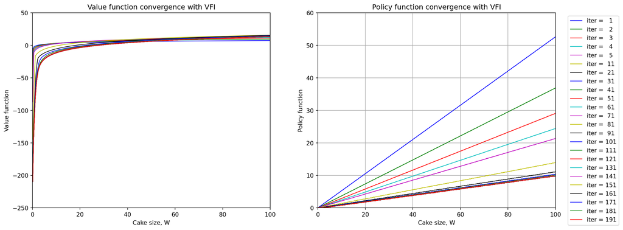

```python
plt.rcParams["axes.autolimit_mode"] = "round_numbers"
plt.rcParams["axes.xmargin"] = 0
plt.rcParams["axes.ymargin"] = 0
plt.rcParams["patch.force_edgecolor"] = True
plt.rcParams["axes.prop_cycle"] = cycler(color="bgrcmyk")

fig1, (ax1, ax2) = plt.subplots(1, 2, figsize=(16, 6))
plt.grid(which="both", color="0.65", linestyle="-")

ax1.set_title("Value function convergence with VFI")
ax1.set_xlabel("Cake size, W")
ax1.set_ylabel("Value function")

ax2.set_title("Policy function convergence with VFI")
ax2.set_xlabel("Cake size, W")
ax2.set_ylabel("Policy function")

def plot_value_convergence(iter, grid, v, c):
    """Callback function for DP solver"""
    if iter < 5 or iter % 10 == 0:
        ax1.plot(grid[1:], v[1:], label=f"iter = {iter+1:3d}", linewidth=1)
        ax2.plot(grid[1:], c[1:], label=f"iter = {iter+1:3d}", linewidth=1)

model1_V, model1_c = model1.solution_ongrid(callback=plot_value_convergence)
plt.legend(loc='upper left', bbox_to_anchor=(1.04, 1))
plt.ion()
plt.show()
```

Second, I want to compare the numerical solution with the analytical solution. To do this, I will first define a function that calculate the analytical value function and consumption function for any model parameters. Then I will contrast the numerical solution with the analytical solution.

```python
def analytical_solution(w, model):
    beta = model.beta
    value_func = (
        np.log(w) / (1 - beta)
        + np.log(1 - beta) / (1 - beta)
        + beta * np.log(beta) / ((1 - beta) ** 2)
    )
    consump_func = (1 - beta) * w
    return value_func, consump_func

model1_V_true, model1_c_true = analytical_solution(model1.grid_w, model1)
```

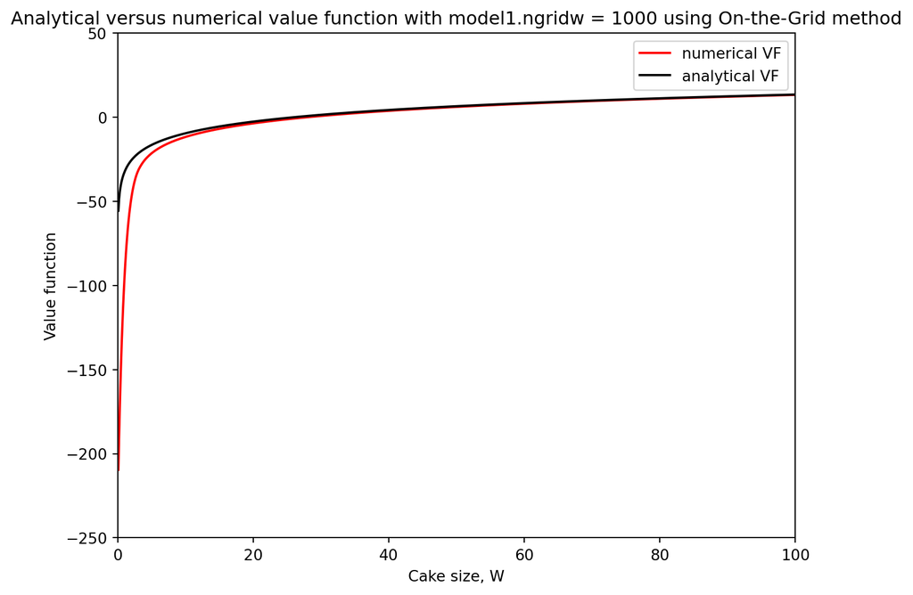

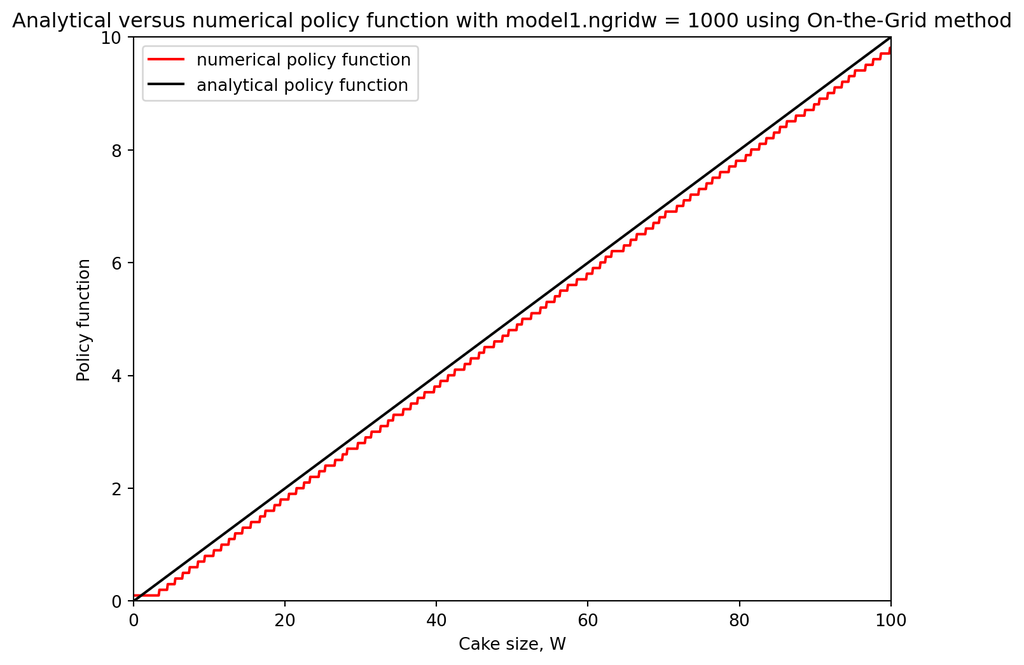

```python
figV, axV = plt.subplots(figsize=(8, 6))
axV.set_title(
    f"Analytical versus numerical value function with {model1.ngridw = } using On-the-Grid method"
)
axV.set_xlabel("Cake size, W")
axV.set_ylabel("Value function")

axV.plot(
    model1.grid_w[1:],
    model1_V[1:],
    c="red",
    label="numerical VF",
)
axV.plot(
    model1.grid_w[1:],
    model1_V_true[1:],
    c="black",
    label="analytical VF",
)
axV.legend()
plt.ion()
plt.show()


figC, axC = plt.subplots(figsize=(8, 6))
axC.set_title(
    f"Analytical versus numerical policy function with {model1.ngridw = } using On-the-Grid method"
)
axC.set_xlabel("Cake size, W")
axC.set_ylabel("Policy function")

axC.plot(
    model1.grid_w[1:],
    model1_c[1:],
    c="red",
    label="numerical policy function",
)
axC.plot(
    model1.grid_w[1:],
    model1_c_true[1:],
    c="black",
    label="analytical policy function",
)
axC.legend()
plt.ion()
plt.show()
```

## 1.3 Discretization Solution Method: Discretize both $W$ and $c$

### 1.3.1 Algorithm: Interpolation + Discretized $c$

To improve accuracy, we can go back to the original Bellman equation,

$$V(W_t) = \max_{0 \leq c_t \leq W_t} \left\{u(c_t) + \beta V(\underbrace{W_{t+1}}_{=W_t - c_t} )\right\},$$

and we treat $c_t$ as our direct choice variable.

Again, there is no guarantee that $W_t - c_t$ lies on the grid $\overrightarrow{W}$. To address this problem, we use a simple interpolation function `scipy.interpolate.interp1d`. I won’t take the credibility of the interpolation method seriously in this note, as the main focus is to develop good-quality and reader-friendly Python codes.

### 1.3.2 Coding up the DIscretization Method

```python
import numpy as np
import matplotlib.pyplot as plt
from scipy import interpolate
from cycler import cycler

# && type hinting relevant variables
from typing import Annotated, Literal, TypeVar, Union
import numpy.typing as npt

DType = TypeVar("DType", bound=np.generic)

ArrayNxN = Annotated[npt.NDArray[DType], Literal["ngridw", "ngridw"]]
ArrayNxNc = Annotated[npt.NDArray[DType], Literal["ngridw", "ngridc"]]
ArrayN = Annotated[npt.NDArray[DType], Literal["ngridw"]]
Collection_float = Union[ArrayN[np.float64], ArrayNxN[np.float64], np.float64]
Numerical_pars = Union[dict[str, float], dict[str, int]]


class CakeEating:
    """
    This class solves the cake-eating problems using different numerical
    methods.

    Through this script, I hope to be more familiar with creating a
    Python class to represent an economics model, and to be more
    familiar with NumPy type hinting to track the calculation process,
    and to perform unit tests when developing codes.
    """

    def __init__(
        self,
        beta: float = 0.9,
        w0: float = 10,
        **kwargs: Numerical_pars,
    ) -> None:
        """
        Initialize an object instance with model parameters, and
        possibly numerical parameters.
        """

        # -? model parameters
        self.beta = beta
        self.w0 = w0

        # -? numerical parameters
        self.kwargs = kwargs
        if "ngridw" in kwargs:
            assert isinstance(
                kwargs["ngridw"], int
            ), "ngridw should be an integer!"
            self.ngridw = kwargs["ngridw"]
        else:
            self.ngridw = 100

        if "ngridc" in kwargs:
            assert isinstance(
                kwargs["ngridc"], int
            ), "ngridc should be an integer!"
            self.ngridc = kwargs["ngridc"]
        else:
            self.ngridc = 200

        if "adapted_grid_c" in kwargs:
            assert isinstance(
                kwargs["adapted_grid_c"], bool
            ), "adapted_grid_c should be a boolen"
            self.adapted_grid_c = kwargs["adapted_grid_c"]
        else:
            self.adapted_grid_c = True

        if "max_iter" in kwargs:
            assert isinstance(
                kwargs["max_iter"], int
            ), "max_iter should be an integer!"
            self.max_iter = kwargs["max_iter"]
        else:
            self.max_iter = 1000

        if "relative_error" in kwargs:
            assert isinstance(
                kwargs["relative_error"], bool
            ), "relative_error should be a boolen"
            self.relative_error = kwargs["relative_error"]
        else:
            self.relative_error = False

        if "c_min" in kwargs:
            assert isinstance(kwargs["c_min"], float)
            self.c_min = kwargs["c_min"]
        else:
            self.c_min = 1e-10

        if "tol" in kwargs:
            assert isinstance(kwargs["tol"], float)
            self.tol = kwargs["tol"]
        else:
            self.tol = 1e-4

    def __repr__(self) -> str:
        numerical_parameters = [
            str((par, self.kwargs[par])) for par in self.kwargs
        ]
        return (
            f"A simple cake-eating problem with beta = {self.beta:.2f}, "
            f"and initial wealth W_0 = {self.w0:.3f}.\n"
            f"Other non-default numerical parameters are set to "
            f"{', ' .join(numerical_parameters)}."
        )

    @property
    def grid_w(self) -> ArrayN[np.float64]:
        return np.linspace(
            start=self.c_min, stop=self.w0, num=self.ngridw, endpoint=True
        )

    def utility(self, c: Collection_float):
        return np.log(c)

    def bellman_ongrid(self, V0: ArrayN[np.float64]):
        """
        Given last-iteration value function, this method calculates
        next-iteration value function using on-the-grid solution method.
        """
        #!! step 1: check the shape of last-iteration value function
        assert V0.shape == (self.ngridw,)

        #!! step 2: construct a consumption array, where
        #!! arr_c[i, j] == self.grid_w[i] - self.grid_w[j]
        arr_w_prime: ArrayNxN
        arr_w: ArrayNxN
        arr_w, arr_w_prime = np.meshgrid(
            self.grid_w, self.grid_w, indexing="ij"
        )

        arr_c: ArrayNxN = arr_w - arr_w_prime
        arr_c[arr_c < 0] = np.nan
        arr_c[arr_c == 0] = self.c_min

        #!! step 3: construct the next-iteration value function array
        #!! arr_value_prime[i,j]
        #!! = log(self.grid_w[i] - self.grid_w[j]) + beta * V0[j]
        arr_V0: ArrayNxN
        _, arr_V0 = np.meshgrid(V0, V0, indexing="ij")
        arr_value_prime = self.utility(arr_c) + self.beta * arr_V0

        #!! step 4: get the next-iteration value function
        #!! maximization over j, i.e., across columns
        V_prime = np.nanmax(arr_value_prime, axis=1)

        #!! step 4: get the consumption function
        c_index = list(np.nanargmax(arr_value_prime, axis=1))
        c = arr_c[list(range(self.ngridw)), c_index]

        return V_prime, c

    def solution_ongrid(self, callback=None):
        """
        This method solves the cake eating problem using on-the-grid method.
        """
        V0 = np.log(self.grid_w)

        for iter in range(self.max_iter):
            print(f"Iteration: {iter+1}\n")
            V1, c = self.bellman_ongrid(V0)
            if callback is not None:
                callback(iter, self.grid_w, V1, c)
            if self.relative_error:
                if np.all(np.abs(V1 - V0) / np.abs(V0) < self.tol):
                    break
            else:
                if np.all(abs(V1 - V0) < self.tol):
                    break
            V0 = V1
        else:
            raise RuntimeError(
                f"Failed to converge in {self.max_iter} iterations."
            )
        return V1, c

    @property
    def arr_c(self) -> ArrayNxNc:
        """
        This method returns the consumption array.
        arr_c[i, :] is the consumption grid when wealth level is self.grid_w[i].
        """
        if self.adapted_grid_c:
            arr_c = np.zeros(shape=(self.ngridw, self.ngridc))
            for w_index in range(self.ngridw):
                arr_c[w_index, :] = np.linspace(
                    start=self.c_min, stop=self.grid_w[w_index], num=self.ngridc
                )
        else:
            grid_c = np.linspace(
                start=self.c_min, stop=self.w0, num=self.ngridc
            )
            _, arr_c = np.meshgrid(self.grid_w, grid_c, indexing="ij")

        assert arr_c.shape == (self.ngridw, self.ngridc)
        return arr_c

    def bellman_discretization(self, V0: ArrayN[np.float64]):
        assert V0.shape == (self.ngridw,)

        #!! arr_w_prime[i, j] = arr_w[i, j] - self.arr_c[i, j]
        #!! = grid_w[i] - self.arr_c[i, j]
        arr_w = ArrayNxNc[np.float64]
        arr_w = np.tile(self.grid_w.reshape((self.ngridw, 1)), reps=self.ngridc)
        arr_w_prime = arr_w - self.arr_c
        arr_w_prime[arr_w_prime < 0] = np.nan
        arr_w_prime[arr_w_prime == 0] = self.c_min

        interp = interpolate.interp1d(
            self.grid_w,
            V0,
            bounds_error=False,
            fill_value="extrapolate",
        )

        arr_V1 = self.utility(self.arr_c) + self.beta * interp(arr_w_prime)

        V1 = np.nanmax(arr_V1, axis=1)
        c_index = list(np.nanargmax(arr_V1, axis=1))
        c = self.arr_c[list(range(self.ngridw)), c_index].ravel()

        return V1, c

    def solution_discretization(self, callback=None):
        """
        This method solves the cake eating problem using on-the-grid method.
        """
        V0 = np.log(self.grid_w)

        for iter in range(self.max_iter):
            # print(f"Iteration: {iter+1}\n")
            V1, c = self.bellman_discretization(V0)
            if callback is not None:
                callback(iter, self.grid_w, V1, c)
            if self.relative_error:
                if np.all(np.abs(V1 - V0) / np.abs(V0) < self.tol):
                    print(f"Final iteration: {iter+1:3d}")
                    break
            else:
                if np.all(abs(V1 - V0) < self.tol):
                    break
            V0 = V1
        else:
            raise RuntimeError(
                f"Failed to converge in {self.max_iter} iterations."
            )
        return V1, c
```

**1**

When performing the discretization method, we need another consumption grid. However, since we may want an adapted consumption grid, that is, we may want the grid to vary by different wealth level, we will need a consumption array, where the row index indicates the wealth grid index. For each row, there is a consumption grid, which is the same across rows if `adapted_grid_c==False`, and different if `adapted_grid_c==True`.

**2**

Similarly, after developping this attribute, we need to test it, using the unit test framework, or simply printing out the resulting consumption arrays.

**3**

Now, the shape of the consumption array is `(ngridw, ngridc)`, we also need the wealth array to be of the same shape, and we are implementing this using the `np.tile()` function.

**4**

Interpolation is needed in the discretization solution method.

### 1.3.3 Testing the Numerical Solutions

First, I will use a relatively fine grids on both wealth and consumption, with the same model parameters as `model1`.

```
Final iteration: 205
```

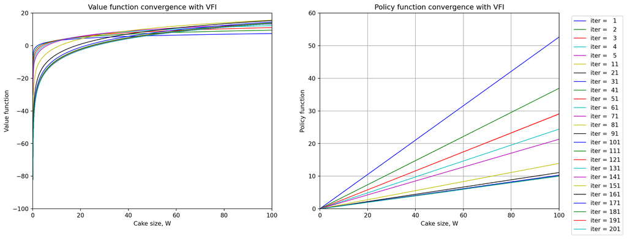

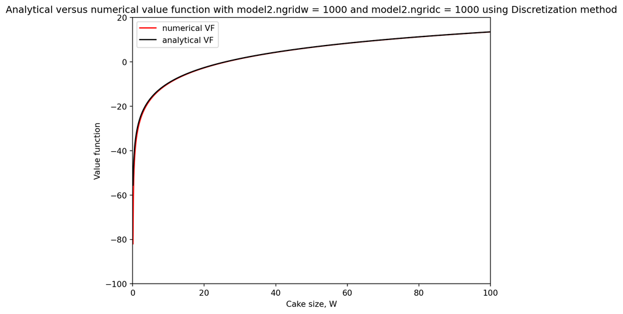

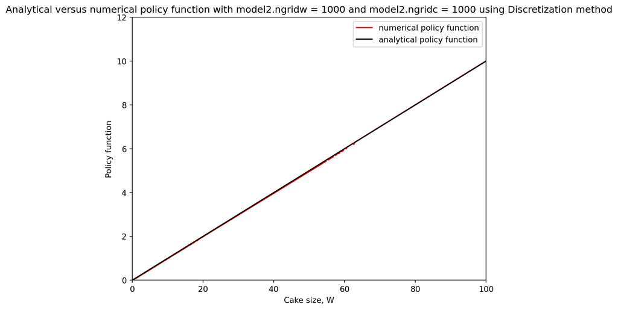

```python
model2 = CakeEating(
    beta=0.9,
    w0=100,
    ngridw=1000,
    ngridc=1000,
    adapted_grid_c=True,
    tol=1e-6,
    relative_error=True
)

# -?#-?#-?#-?#-?#-?#-?#-?#-?#-?#-?#-?#-?#-?#-?#-?#-?#-?#-?#-?#-?#-?
# -? test for convergence
# -?#-?#-?#-?#-?#-?#-?#-?#-?#-?#-?#-?#-?#-?#-?#-?#-?#-?#-?#-?#-?#-?

plt.rcParams["axes.autolimit_mode"] = "round_numbers"
plt.rcParams["axes.xmargin"] = 0
plt.rcParams["axes.ymargin"] = 0
plt.rcParams["patch.force_edgecolor"] = True
plt.rcParams["axes.prop_cycle"] = cycler(color="bgrcmyk")

fig1, (ax1, ax2) = plt.subplots(1, 2, figsize=(16, 6))
plt.grid(which="both", color="0.65", linestyle="-")

ax1.set_title("Value function convergence with VFI")
ax1.set_xlabel("Cake size, W")
ax1.set_ylabel("Value function")

ax2.set_title("Policy function convergence with VFI")
ax2.set_xlabel("Cake size, W")
ax2.set_ylabel("Policy function")


def plot_value_convergence(iter, grid, v, c):
    """Callback function for DP solver"""
    if iter < 5 or iter % 10 == 0:
        ax1.plot(grid[1:], v[1:], label=f"iter = {iter+1:3d}", linewidth=1)
        ax2.plot(grid[1:], c[1:], label=f"iter = {iter+1:3d}", linewidth=1)


model2_V, model2_c = model2.solution_discretization(callback=plot_value_convergence)
plt.legend(loc="upper left", bbox_to_anchor=(1.04, 1))
plt.ion()
plt.show()

# -?#-?#-?#-?#-?#-?#-?#-?#-?#-?#-?#-?#-?#-?#-?#-?#-?#-?#-?#-?#-?#-?
# -? compare with numerical solutions
# -?#-?#-?#-?#-?#-?#-?#-?#-?#-?#-?#-?#-?#-?#-?#-?#-?#-?#-?#-?#-?#-?

def analytical_solution(w, model):
    beta = model.beta
    value_func = (
        np.log(w) / (1 - beta)
        + np.log(1 - beta) / (1 - beta)
        + beta * np.log(beta) / ((1 - beta) ** 2)
    )
    consump_func = (1 - beta) * w
    return value_func, consump_func


model2_V_true, model2_c_true = analytical_solution(model2.grid_w, model2)


figV, axV = plt.subplots(figsize=(8, 6))
axV.set_title(
    f"Analytical versus numerical value function with {model2.ngridw = } and {model2.ngridc = } using Discretization method"
)
axV.set_xlabel("Cake size, W")
axV.set_ylabel("Value function")

axV.plot(
    model2.grid_w[1:],
    model2_V[1:],
    c="red",
    label="numerical VF",
)
axV.plot(
    model2.grid_w[1:],
    model2_V_true[1:],
    c="black",
    label="analytical VF",
)
axV.legend()
plt.ion()
plt.show()


figC, axC = plt.subplots(figsize=(8, 6))
axC.set_title(
    f"Analytical versus numerical policy function with {model2.ngridw = } and {model2.ngridc = } using Discretization method"
)
axC.set_xlabel("Cake size, W")
axC.set_ylabel("Policy function")

axC.plot(
    model2.grid_w[1:],
    model2_c[1:],
    c="red",
    label="numerical policy function",
)
axC.plot(
    model2.grid_w[1:],
    model2_c_true[1:],
    c="black",
    label="analytical policy function",
)
axC.legend()
plt.ion()
plt.show()
```

With the same size of wealth grid, the numerical solutions using the discretization method are more accurate than the on-the-gird method, with a cost of increasing computational time. You may think the discretization method is good enough. However, the truth is, the resulting consumption rule is still weird – it is not even monotone. And this is the most severe drawback of these discretization-based numerical solution – the numerical results may even not share the same monotonicity or concavity properties as the true, analytical solutions. In some economics applications, this could be detrimental for our analysis.

To see this point, we can zoom in, and check a specific region of the resulting policy function:

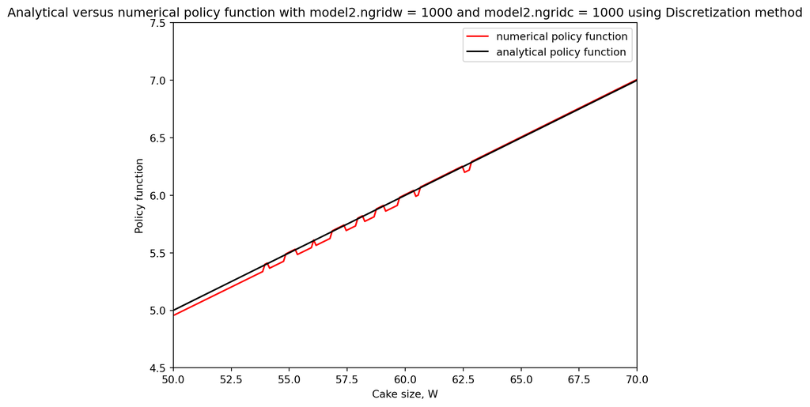

```python
figC, axC = plt.subplots(figsize=(8, 6))
axC.set_title(
    f"Analytical versus numerical policy function with {model2.ngridw = } and {model2.ngridc = } using Discretization method"
)
axC.set_xlabel("Cake size, W")
axC.set_ylabel("Policy function")

axC.plot(
    model2.grid_w[500:700],
    model2_c[500:700],
    c="red",
    label="numerical policy function",
)
axC.plot(
    model2.grid_w[500:700],
    model2_c_true[500:700],
    c="black",
    label="analytical policy function",
)
axC.legend()
plt.ion()
plt.show()
```